# Proyecto1

Orlando Vásquez

2026-06-06

# 1 Definición del Problema

Se dispone de un dataset con información sociodemográfica de individuos (edad, ingreso, nivel educativo, profesión, entre otros), el cual presenta múltiples problemas de calidad como:

- Datos faltantes
- Registros duplicados
- Inconsistencias en variables categóricas
- Valores atípicos (outliers)
- Datos erróneos (por ejemplo, ingresos negativos o edades irreales)

El problema consiste en:

Preparar y transformar el dataset para que sea apto para el entrenamiento de modelos de machine learning que apoyen la toma de decisiones.

# 2 Objetivo general

Desarrollar un proceso completo de limpieza, transformación y preparación de datos que permita construir un dataset confiable y adecuado para aplicar técnicas de aprendizaje automático.

# 3 Objetivos específicos

## 3.1 Identificar problemas de calidad de datos

Detectar valores faltantes, duplicados e inconsistencias.

## 3.2 Realizar limpieza de datos

Tratar valores nulos. Eliminar o corregir registros erróneos. Gestionar datos atípicos.

## 3.3 Estandarizar variables

Unificar formatos de texto (mayúsculas/minúsculas). Normalizar categorías (género, ciudad, estado civil).

## 3.4 Transformar variables

Codificar variables categóricas (One-Hot, Ordinal). Escalar variables numéricas.

## 3.5 Realizar ingeniería de características

Crear nuevas variables (ej. ingreso per cápita, nombre completo). Seleccionar variables relevantes.

## 3.6 Preparar el dataset final

Dividir en entrenamiento y prueba.

## 3.7 Exportar datos

# 4 Cargar los Datos

Verificar que se tienen el archivo a trabajar en la carpeta Datos

```r
list.files("../Datos") # Verificar que archivos están en el proyecto
```

```
## [1] "dataset_clase_1.csv"
```

```r
data <- read.csv("../Datos/dataset_clase_1.csv")
```

```r
data
```

```
##    ID    Nombre  Apellido Edad Ingreso    Genero   Ciudad     Profesion
## 1   1      Juan     Pérez   25    1200 MASCULINO   Bogotá     Ingeniero
## 2   2       Ana     Gómez   30    1500  Femenino Medellín       Abogada
## 3   3    Carlos     Lopez   45    3000 MASCULINO     Cali        Medico
## 4   4     María Rodríguez   29      NA  FEMENINO   Bogotá       Docente
## 5   5     Pedro  Martinez   35   -2000 Masculino   bogotá   Comerciante
## 6   6     Luisa Hernandez   NA    1800  FEMENINO     Cali     Ingeniera
## 7   7      Juan     Pérez   25    1200 MASCULINO   Bogotá     Ingeniero
## 8   8    Andres    Garcia   40   50000 MASCULINO Medellín    Empresario
## 9   9     Sofía      Diaz   22    1100  Femenino     Cali    Estudiante
## 10 10    Camilo    torres   28    1300 MASCULINO   Bogotá     Ingeniero
## 11 11     Laura  Martínez   31    1400  Femenino Medellín     Psicologa
## 12 12     Diego   Ramirez   50       0 MASCULINO     Cali      Contador
## 13 13 Valentina    Castro   27    1250  FEMENINO   Bogotá    Diseñadora
## 14 14      José    Suarez   33      NA MASCULINO Medellín     Ingeniero
```

[output cut: 47 more lines]

## 4.1 Exploración de Datos

```r
head(data)
```

```
##   ID Nombre  Apellido Edad Ingreso    Genero   Ciudad   Profesion
## 1  1   Juan     Pérez   25    1200 MASCULINO   Bogotá   Ingeniero
## 2  2    Ana     Gómez   30    1500  Femenino Medellín     Abogada
## 3  3 Carlos     Lopez   45    3000 MASCULINO     Cali      Medico
## 4  4  María Rodríguez   29      NA  FEMENINO   Bogotá     Docente
## 5  5  Pedro  Martinez   35   -2000 Masculino   bogotá Comerciante
## 6  6  Luisa Hernandez   NA    1800  FEMENINO     Cali   Ingeniera
##   Nivel_Educativo Estado_Civil Hijos               Email
## 1   Universitario      SOLTERO     0     juanp@gmail.com
## 2 Especialización       Casada     1 ana.gomez@gmail.com
## 3        Maestría       CASADO     2   carlosl@gmail.com
## 4   Universitario      Soltera     0     maria@gmail.com
## 5       Bachiller  UNION LIBRE     3     pedro@gmail.com
## 6   Universitario      Soltera     0     luisa@gmail.com
```

## 4.2 Dimensiones del dataset

```r
dim(data)
```

```
## [1] 30 12
```

## 4.3 Conocer el nombre de las columnas (variables)

```r
colnames(data)
```

```
##  [1] "ID"              "Nombre"          "Apellido"        "Edad"
##  [5] "Ingreso"         "Genero"          "Ciudad"          "Profesion"
##  [9] "Nivel_Educativo" "Estado_Civil"    "Hijos"           "Email"
```

## 4.4 Estructura de los datos

```r
str(data)
```

```
## 'data.frame':    30 obs. of  12 variables:
##  $ ID             : int  1 2 3 4 5 6 7 8 9 10 ...
##  $ Nombre         : chr  "Juan" "Ana" "Carlos" "María" ...
##  $ Apellido       : chr  "Pérez" "Gómez" "Lopez" "Rodríguez" ...
##  $ Edad           : num  25 30 45 29 35 NA 25 40 22 28 ...
##  $ Ingreso        : num  1200 1500 3000 NA -2000 1800 1200 50000 1100 1300 ...
##  $ Genero         : chr  "MASCULINO" "Femenino" "MASCULINO" "FEMENINO" ...
##  $ Ciudad         : chr  "Bogotá" "Medellín" "Cali" "Bogotá" ...
##  $ Profesion      : chr  "Ingeniero" "Abogada" "Medico" "Docente" ...
##  $ Nivel_Educativo: chr  "Universitario" "Especialización" "Maestría" "Universitario" ...
##  $ Estado_Civil   : chr  "SOLTERO" "Casada" "CASADO" "Soltera" ...
##  $ Hijos          : int  0 1 2 0 3 0 0 2 0 0 ...
##  $ Email          : chr  "juanp@gmail.com" "ana.gomez@gmail.com" "carlosl@gmail.com" "maria@gmail.com" ...
```

El conjunto de datos contiene 30 observaciones y 12 variables, combinando información numérica y categórica sobre características demográficas, económicas y sociales de las personas registradas. Entre las variables cuantitativas se encuentran la edad, el ingreso y el número de hijos, mientras que las variables cualitativas incluyen género, ciudad, profesión, nivel educativo y estado civil. La estructura muestra que existen algunos valores perdidos en variables como edad e ingreso, además de inconsistencias en la escritura de categorías, por ejemplo diferencias entre mayúsculas y minúsculas (“MASCULINO” y “Masculino”) y variaciones en acentos. También se observan posibles valores atípicos, como una edad de 200 años y un ingreso de 50000, que podrían afectar el análisis estadístico. En general, la base es adecuada para aplicar procesos de limpieza, transformación y análisis exploratorio de datos, permitiendo estudiar patrones relacionados con características personales, económicas y educativas de la población registrada.

## 4.5 Distribución frecuencias por columna

```r
freq_profesion <- table(data$Profesion)
freq_profesion
```

```
##
##       Abogada Administrador   Comerciante      Contador    Diseñadora
##             2             2             2             2             2
##       Docente    Empresario    Estudiante     Ingeniera     Ingeniero
##             3             2             3             1             8
##        Medico     Psicologa
##             1             2
```

### 4.5.1 Mejor Presentación usando tablas

```r
freq_profesion <- data.frame(sort(table(data$Profesion),
                                      decreasing = TRUE))

colnames(freq_profesion) <- c("Profesion", "Frecuencia")

freq_profesion
```

```
##        Profesion Frecuencia
## 1      Ingeniero          8
## 2        Docente          3
## 3     Estudiante          3
## 4        Abogada          2
## 5  Administrador          2
## 6    Comerciante          2
## 7       Contador          2
## 8     Diseñadora          2
## 9     Empresario          2
## 10     Psicologa          2
## 11     Ingeniera          1
## 12        Medico          1
```

La variable Profesión presenta una alta diversidad ocupacional, siendo Ingeniero la profesión más frecuente con 8 registros, lo que indica un predominio del área de ingeniería dentro del conjunto de datos. Otras profesiones con presencia moderada son Docente y Estudiante, con 3 registros cada una. Además, varias categorías aparecen con frecuencias similares, como Abogada, Administrador, Comerciante, Contador, Diseñadora, Empresario y Psicóloga, cada una con 2 observaciones. También se identifican profesiones con una sola aparición, como Ingeniera y Médico. Se observa una posible inconsistencia en la variable debido al uso de formas masculinas y femeninas para una misma profesión, por ejemplo, Ingeniero e Ingeniera, lo que sugiere la necesidad de estandarizar las categorías antes de realizar análisis más precisos.

```r
freq_ciudad <- table(data$Ciudad)
freq_ciudad
```

```
##
##   bogota   bogotá   Bogotá     Cali Medellín
##        1        1       11        9        8
```

```r
freq_ciudad <- data.frame(sort(table(data$Ciudad),
                                      decreasing = TRUE))

colnames(freq_ciudad) <- c("Ciudad", "Frecuencia")

freq_ciudad
```

```
##     Ciudad Frecuencia
## 1   Bogotá         11
## 2     Cali          9
## 3 Medellín          8
## 4   bogota          1
## 5   bogotá          1
```

La variable ciudad presenta una distribución relativamente concentrada en tres ciudades principales: Bogotá con 11 registros, Cali con 9 y Medellín con 8. Sin embargo, se observan inconsistencias en la escritura de la categoría Bogotá, ya que también aparecen las variantes “bogota” y “bogotá” en minúsculas y con diferencias en el uso de tildes. Aunque representan la misma ciudad, el sistema las interpreta como categorías diferentes, generando duplicidad y afectando los análisis de frecuencia. Este tipo de problema es común en bases de datos reales y evidencia la necesidad de realizar procesos de limpieza y estandarización de texto, como convertir todos los registros a mayúsculas o minúsculas y unificar el uso de caracteres especiales antes de efectuar análisis estadísticos o visualizaciones.

```r
freq_genero <- table(data$Genero)
freq_genero <- data.frame(sort(table(data$Genero),
                                      decreasing = TRUE))

colnames(freq_ciudad) <- c("Genero", "Frecuencia")

freq_genero
```

```
##        Var1 Freq
## 1 MASCULINO   16
## 2  Femenino    8
## 3  FEMENINO    5
## 4 Masculino    1
```

La variable Género presenta inconsistencias en la forma de registrar las categorías, ya que aparecen diferencias en el uso de mayúsculas y minúsculas. La categoría más frecuente es MASCULINO con 16 registros, seguida de Femenino con 8 y FEMENINO con 5. Además, aparece un registro como Masculino con 1 observación. Esto evidencia problemas de estandarización en los datos, puesto que categorías equivalentes están siendo tratadas como diferentes. Antes de realizar análisis estadísticos o visualizaciones, es recomendable unificar los valores en categorías únicas, por ejemplo, “Masculino” y “Femenino”, para evitar sesgos en los resultados y obtener frecuencias reales.

```r
freq_estado <- table(data$Estado_Civil)
freq_estado <- data.frame(sort(table(data$Estado_Civil),
                                      decreasing = TRUE))

colnames(freq_ciudad) <- c("Estado_Civil", "Frecuencia")

freq_estado
```

```
##          Var1 Freq
## 1     Soltera   10
## 2      Casado    8
## 3     SOLTERO    4
## 4      Casada    3
## 5     Soltero    2
## 6      CASADO    1
## 7 Union libre    1
## 8 UNION LIBRE    1
```

La variable Estado Civil presenta inconsistencias en la escritura de las categorías, lo que evidencia problemas de estandarización en los datos. Por ejemplo, aparecen registros como “Soltera”, “SOLTERO” y “Soltero”, así como “Casado”, “CASADO” y “Casada”, que representan esencialmente las mismas categorías pero con diferencias en mayúsculas, género o formato de escritura. La categoría más frecuente es “Soltera” con 10 registros, seguida de “Casado” con 8 registros. También se identifican registros de “Union libre” y “UNION LIBRE”, que igualmente deberían unificarse. Estas inconsistencias pueden afectar los análisis estadísticos y las visualizaciones, ya que el sistema interpreta cada variación como una categoría distinta. Por ello, se recomienda realizar un proceso de limpieza y normalización de texto, convirtiendo todas las categorías a un mismo formato antes de analizar la variable.

```r
freq_profesion <- table(data$Estado_Civil)
freq_profesion <- data.frame(sort(table(data$Profesion),
                                      decreasing = TRUE))

colnames(freq_profesion) <- c("Profesion", "Frecuencia")

freq_profesion
```

```
##        Profesion Frecuencia
## 1      Ingeniero          8
## 2        Docente          3
## 3     Estudiante          3
## 4        Abogada          2
## 5  Administrador          2
## 6    Comerciante          2
## 7       Contador          2
## 8     Diseñadora          2
## 9     Empresario          2
## 10     Psicologa          2
## 11     Ingeniera          1
## 12        Medico          1
```

La variable Profesión presenta una alta diversidad ocupacional, siendo Ingeniero la profesión más frecuente con 8 registros, lo que indica un predominio del área de ingeniería dentro del conjunto de datos. Otras profesiones con presencia moderada son Docente y Estudiante, con 3 registros cada una. Además, varias categorías aparecen con frecuencias similares, como Abogada, Administrador, Comerciante, Contador, Diseñadora, Empresario y Psicóloga, cada una con 2 observaciones. También se identifican profesiones con una sola aparición, como Ingeniera y Médico. Se observa una posible inconsistencia en la variable debido al uso de formas masculinas y femeninas para una misma profesión, por ejemplo, Ingeniero e Ingeniera, lo que sugiere la necesidad de estandarizar las categorías antes de realizar análisis más precisos.

## 4.6 Análisis de variables Cuantitativas

### 4.6.1 Edad

```r
summary(data$Edad)
```

```
##    Min. 1st Qu.  Median    Mean 3rd Qu.    Max.     NAs
##   22.00   25.75   29.50   38.29   37.25  200.00       2
```

La variable edad presenta una distribución concentrada principalmente entre 25 y 37 años, ya que el primer cuartil es 25.75 y el tercer cuartil es 37.25. La mediana es de 29.5 años, lo que indica que la mitad de las personas tiene menos de 30 años aproximadamente. Sin embargo, la media es de 38.29 años, considerablemente mayor que la mediana, lo cual sugiere la presencia de valores atípicos que elevan el promedio. Esto se confirma con el valor máximo registrado de 200 años, un dato poco realista que probablemente corresponde a un error de digitación o captura. Además, se identificaron 2 valores faltantes (NA’s), por lo que se recomienda realizar un proceso de limpieza de datos antes de continuar con análisis más avanzados.

### 4.6.2 Análisis Ingreso

[output not shown]

La variable ingresos presenta una alta dispersión en los datos. El valor mínimo registrado es de −2000, lo cual resulta poco realista para un ingreso y probablemente corresponde a un error de digitación, un valor incorrecto o un caso especial como deudas o pérdidas no especificadas. El primer cuartil es 1200 y el tercer cuartil 1625, lo que indica que el 50% central de los ingresos se concentra en ese rango. La mediana es de 1325, mientras que la media asciende a 3200, mostrando una diferencia considerable causada por valores extremadamente altos. Esto se confirma con el valor máximo de 50000, que actúa como un valor atípico (outlier) y eleva significativamente el promedio. Además, existen 2 valores faltantes (NA), por lo que antes de realizar análisis estadísticos o modelos predictivos se debe tratar los valores nulos y revisar tanto los ingresos negativos como los valores excesivamente altos.

## 4.7 Histograma para analizar distribución variables - Diagrama de cajas

### 4.7.1 Ingreso

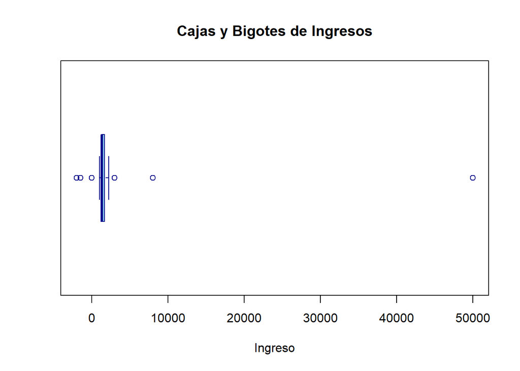

```r
boxplot(
  data$Ingreso,
  horizontal = TRUE,
  col = "skyblue",
  border = "darkblue",
  main = "Cajas y Bigotes de Ingresos",
  xlab = "Ingreso"
)
```

El boxplot de la variable Ingreso muestra una distribución altamente asimétrica hacia la derecha. La mayoría de los ingresos se concentran en valores relativamente bajos, aproximadamente entre 1000 y 2000, lo cual se evidencia por la caja pequeña y cercana al origen. Sin embargo, aparecen varios valores atípicos (outliers), especialmente uno extremadamente alto cercano a 50000, que provoca una gran dispersión en la escala y desplaza visualmente el resto de los datos hacia la izquierda. También se observan algunos ingresos negativos, lo que podría indicar errores de digitación o situaciones particulares en los datos. Debido a estos valores extremos, la media de los ingresos probablemente sea mucho mayor que la mediana, indicando que unos pocos ingresos altos influyen significativamente en el promedio general.

### 4.7.2 Edad

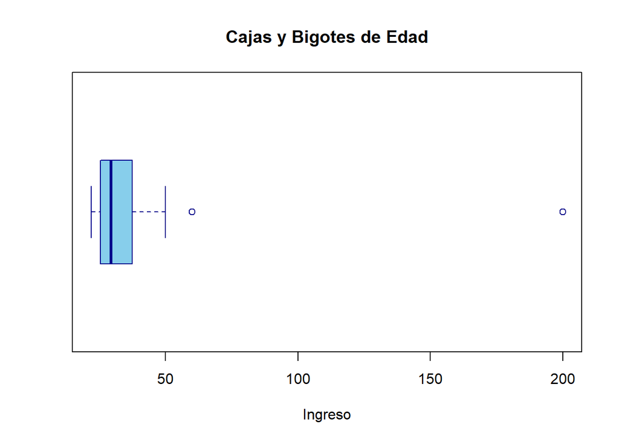

```r
boxplot(
  data$Edad,
  horizontal = TRUE,
  col = "skyblue",
  border = "darkblue",
  main = "Cajas y Bigotes de Edad",
  xlab = "Ingreso"
)
```